# An Analysis of Subjectivity in Brazilian News - KDMILe 2019

Este notebook implementa a análise realizada no artigo An Analysis of Subjectivity in Brazilian News publicado no KDMILe- 2019. Para guiar a pesquisa, são definidas $4$ questões de pesquisa (QP) apresentadas a seguir. Acreditamos que o método usado, juntamente com as respostas obtidas a essas questões, contribuem para um melhor entendimento sobre as características linguísticas das notícias que consumimos diariamente.

A validação do método utilizado para estimava de subjetividade por ser encontrada no artigo. Todos os resultados dos experimentos a seguir são retratadospor intervalos com95%de confiança estimados a partir de2000re-amostragens de tamanho aleatório,computadas por meio debootstrapingcom reposição.

```r
options(warn=-1) # ignore warns
require(GGally, quietly = TRUE)
require(reshape2, quietly = TRUE)
require(tidyverse, quietly = TRUE, warn.conflicts = FALSE)
library(ggfortify)
library(cluster)
library(broom)
library(tidyverse)
library(plotly)
library(resample)
library(lubridate)
library(ggpubr)
library(here)
```

## Os dados

Foram coletadas notícias e comentários dos cadernos de esporte e política dos portais Estadão, Folha de São Paulo,O Antagonista,O Globo e Veja durante o período de janeiro à dezembro de 2018. Em 2018, os cadernos de esporte e política cobriram eventos como a copa do mundo de futebolmasculino7e as eleições presidenciais brasileiras8, momentos especialmente interessantes de seremanalisados devido a uma maior tendencia das notícias serem apresentadas de forma mais subjetiva,de acordo com o posicionamento esportivo/político do seu editor.

```r
#carta_capital <- read_csv(here::here("data/carta_capital.csv")) %>% filter(arg >= 0, sen >= 0, val >= 0, pre >= 0, mod >= 0)
estadao <- read_csv(here::here("data/estadao.csv")) %>% filter(arg >= 0, sen >= 0, val >= 0, pre >= 0, mod >= 0)
folha <- read_csv(here::here("data/folha.csv")) %>% filter(arg >= 0, sen >= 0, val >= 0, pre >= 0, mod >= 0)
oantagonista <- read_csv(here::here("data/oantagonista.csv")) %>% filter(arg >= 0, sen >= 0, val >= 0, pre >= 0, mod >= 0)
oglobo <- read_csv(here::here("data/oglobo.csv")) %>% filter(arg >= 0, sen >= 0, val >= 0, pre >= 0, mod >= 0)
veja <- read_csv(here::here("data/veja.csv")) %>% filter(arg >= 0, sen >= 0, val >= 0, pre >= 0, mod >= 0)

news <-bind_rows(
    #"carta_capital" = carta_capital,
    "estadao" = estadao,
    "folha" = folha,
    "oantagonista" = oantagonista,
    "oglobo" = oglobo,
    "veja" = veja,
    .id = "jornal")

readabilityMetrics <- read_csv(here::here("data/readability_metrics.csv"))

metaData <- read_csv(here::here("data/meta_data.csv")) %>%
  filter(text_size <= 1000 & number_comments <= 1000) # remove outliers
```

# QP1: Como se comparam os níveis de subjetividade entre os jornais considerados?

A gráfico abaixo retrata o intervalo de confiança do percentual médio de subjetividade para cada portal.

```r
biasNews <- news %>%
  mutate(bias_news = (1 - (arg + sen + val + pre + mod) / 5)) %>%
  select(jornal, url, bias_news)

resamples = 2000

subj_estadao <- biasNews %>%
  filter(jornal == "estadao") %>%
  bootstrap(median(bias_news),
            R = resamples) %>%
    CI.percentile(probs = c(.025, .975))


subj_folha <- biasNews %>%
  filter(jornal == "folha") %>%
  bootstrap(median(bias_news),
            R = resamples) %>%
    CI.percentile(probs = c(.025, .975))

subj_oantagonista <- biasNews %>%
  filter(jornal == "oantagonista") %>%
  bootstrap(median(bias_news),
            R = resamples) %>%
    CI.percentile(probs = c(.025, .975))

subj_oglobo <- biasNews %>%
  group_by(jornal == "oglobo") %>%
  bootstrap(median(bias_news),
            R = resamples) %>%
    CI.percentile(probs = c(.025, .975))

subj_veja <- biasNews %>%
  group_by(jornal == "veja") %>%
  bootstrap(median(bias_news),
            R = resamples) %>%
    CI.percentile(probs = c(.025, .975))

subj_ci = data.frame(rbind(subj_estadao, subj_folha, subj_oantagonista, subj_oglobo, subj_veja))

subj_ci$jornal = c("estadao", "folha", "oantagonista", "oglobo", "veja")
```

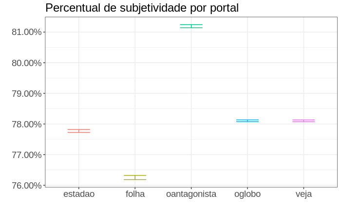

```r
qp1 <- subj_ci %>%
  ggplot(aes(x = jornal, ymin = X2.5., ymax = X97.5., color = jornal)) +
  geom_errorbar(width = .4) +
  labs(title = "Percentual de subjetividade por portal",
       #subtitle = "Estimativa de subjetividade considerando todas as notícias de 2018",
       x = "",
       y = "") +
  scale_y_continuous(labels = scales::percent) +
  theme_bw() +
  theme(legend.position="none",
        axis.text=element_text(size=14),
        plot.title = element_text(size=18)
        )
qp1
```

```r
#ggsave("pp1.png", width = 6, height = 4)
```

# QP2: Há correlação entre subjetividade e legibilidade?

A legibilidade de um texto diz respeito à sua qualidade tipográfica, refletindo em sua facilidade deleitura. Este experimento estima a correlação de Spearman entre subjetividade e $4$ métricas estado-da-arte: `Coleman Liau Index`, `Smog Index`, `Lix Index` e `Dale Chall Score`. Os resultados são retratados a seguir.

```r
readabilityMetrics <- merge(x = readabilityMetrics, y = news, all = TRUE) %>% filter(!is.na(jornal))
readabilityMetrics <- readabilityMetrics %>%
  mutate(bias_news = (1 - (arg + sen + val + pre + mod) / 5) * 100)

coleman <- readabilityMetrics %>%
  bootstrap(cor(bias_news, coleman_liau_index, method = "spearman"),
            R = resamples) %>%
    CI.percentile(probs = c(.025, .975))

smog <- readabilityMetrics %>%
  bootstrap(cor(bias_news, smog_index, method = "spearman"),
            R = resamples) %>%
    CI.percentile(probs = c(.025, .975))

lix <- readabilityMetrics %>%
  bootstrap(cor(bias_news, lix_index, method = "spearman"),
            R = resamples) %>%
    CI.percentile(probs = c(.025, .975))

dale <- readabilityMetrics %>%
  bootstrap(cor(bias_news, dale_chall_score, method = "spearman"),
            R = resamples) %>%
    CI.percentile(probs = c(.025, .975))

read_ci = data.frame(rbind(coleman, smog, lix, dale))
read_ci$coef = c("coleman index", "smog index", "lix index", "dale chall score")
```

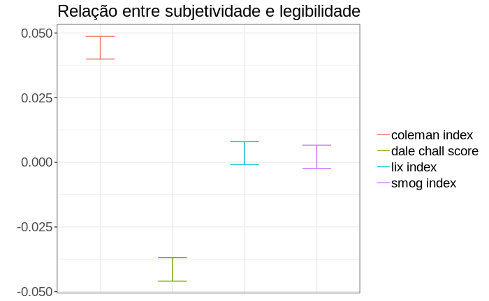

```r
qp2 <- read_ci %>%
  ggplot(aes(x = coef, ymin = X2.5., ymax = X97.5., color = coef)) +
  geom_errorbar(width = .4) +
  labs(title = "Relação entre subjetividade e legibilidade",
       #subtitle = "Estimativa considerando todas as notícias de 2018",
       x = "",
       y = "") +
  theme_bw() +
  theme(legend.text=element_text(size=14),
        axis.text=element_text(size=14),
        plot.title = element_text(size=18),
        legend.title=element_blank(),
        axis.title.x=element_blank(),
        axis.text.x=element_blank(),
        axis.ticks.x=element_blank())
qp2
```

```r
#ggsave("pp2.png", width = 6, height = 4)
```

```r
#ggarrange(qp1, qp2,
#          labels = c("A", "B"),
#          ncol = 2)
#ggsave("fig2-3.pdf", width = 12, height = 4)
```

Para qualquer métrica de legibilidade, os intervalos estimados são próximos de $0$. Ou seja, a correlação existente entre as variáveis é desprezível. Com isso temos indícios de que a subjetividade de uma notícia independe de sua legibilidade.

# QP3: Há correlação entre subjetividade e tamanho da notícia

```r
estadao_len <- readabilityMetrics %>%
  filter(jornal == "estadao") %>%
  bootstrap(cor(bias_news, words, method = "spearman"),
            R = resamples) %>%
    CI.percentile(probs = c(.025, .975))

folha_len <- readabilityMetrics %>%
  filter(jornal == "folha") %>%
  bootstrap(cor(bias_news, words, method = "spearman"),
            R = resamples) %>%
    CI.percentile(probs = c(.025, .975))

oantagonista_len <- readabilityMetrics %>%
  filter(jornal == "oantagonista") %>%
  bootstrap(cor(bias_news, words, method = "spearman"),
            R = resamples) %>%
    CI.percentile(probs = c(.025, .975))

oglobo_len <- readabilityMetrics %>%
  filter(jornal == "oglobo") %>%
  bootstrap(cor(bias_news, words, method = "spearman"),
            R = resamples) %>%
    CI.percentile(probs = c(.025, .975))

veja_len <- readabilityMetrics %>%
  filter(jornal == "veja") %>%
  bootstrap(cor(bias_news, words, method = "spearman"),
            R = resamples) %>%
    CI.percentile(probs = c(.025, .975))

subj_len = data.frame(rbind(estadao_len, folha_len, oantagonista_len, oglobo_len, veja_len))
subj_len$portal = c("estadao", "folha", "oantagonista", "oglobo", "veja")
```

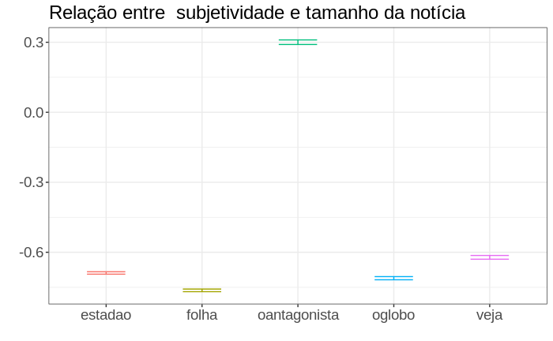

```r
qp3 <- subj_len %>%
  ggplot(aes(x = portal, ymin = X2.5., ymax = X97.5., color = portal)) +
  geom_errorbar(width = .4) +
  labs(title = "Relação entre  subjetividade e tamanho da notícia",
       #subtitle = "Estimativa de correlação entre subjetividade e legibilidade considerando um ano de coleta",
       x = "",
       y = "") +
  theme_bw() +
  theme(legend.position="none", axis.text=element_text(size=14),
         plot.title = element_text(size=18)
        )

qp3
```

```r
#ggsave("pp3.png", width = 6.3, height = 4)
```

O portal `O Antagonista` apresenta correlação positiva entre tamanho e subjetividade enquanto os demais portais apresentam correlações negativas. Dentre os resultados, destacam-se os valores de correlação da `Folha de São Paulo`, `Estadão` e `O Globo`, com valores aproximados de $-0.75$, o que pode ser considerado uma correlação negativa forte, isso mostra uma tendência de que notícias menores são mais subjetivas.

# QP4: Há correlação entre subjetividade e popularidade?

Por fim, este experimento analisa a existência de correção entre subjetividade e popularidade. Aqui, estamos interessados em investigar se notícias mais subjetivas são mais populares, o que pode estar relacionado ao apelo à emoção e/ou técnicas de persuasão comumente empregadas para influenciar os leitores. A visualização abaixo exibe o intervalo de confiança estimado do coeficiente de correlação de `Spearman` por portal. Todos os portais apresentam intervalo próximo de $0$. Assim, há indícios de que a popularidade de uma notícia independe de sua subjetividade.

```r
metaData <- merge(x = news, y = metaData, all = TRUE) %>%
  mutate(bias_news = (1 - (arg + sen + val + pre + mod) / 5) * 100) %>% filter(!is.na(jornal), !is.na(number_comments))

estadao_pop <- metaData %>%
  filter(jornal == "estadao" | jornal == "oglobo") %>%
  bootstrap(cor(bias_news, number_comments, method = "spearman"),
            R = resamples) %>%
    CI.percentile(probs = c(.025, .975))

folha_pop <- metaData %>%
  filter(jornal == "folha" | jornal == "oglobo") %>%
  bootstrap(cor(bias_news, number_comments, method = "spearman"),
            R = resamples) %>%
    CI.percentile(probs = c(.025, .975))

oantagonista_pop <- metaData %>%
  filter(jornal == "oantagonista") %>%
  bootstrap(cor(bias_news, number_comments, method = "spearman"),
            R = resamples) %>%
    CI.percentile(probs = c(.025, .975))

oglobo_pop <- metaData %>%
  filter(jornal == "oglobo") %>%
  bootstrap(cor(bias_news, number_comments, method = "spearman"),
            R = resamples) %>%
    CI.percentile(probs = c(.025, .975))

veja_pop <- metaData %>%
  filter(jornal == "veja") %>%
  bootstrap(cor(bias_news, number_comments, method = "spearman"),
            R = resamples) %>%
    CI.percentile(probs = c(.025, .975))

bias_pop = data.frame(rbind(estadao_pop, folha_pop, oantagonista_pop, oglobo_pop, veja_pop))

bias_pop$portal = c("estadao", "folha", "oantagonista", "oglobo", "veja")
```

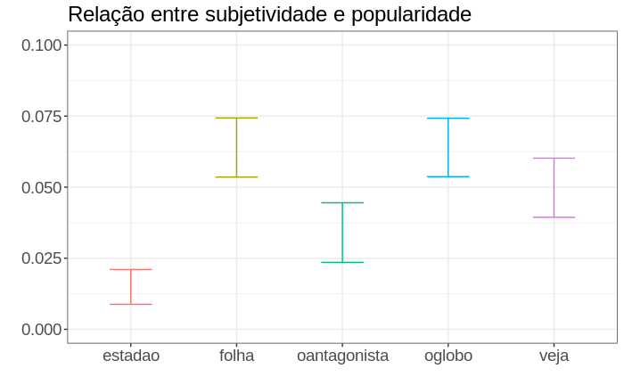

```r
qp4 <- bias_pop %>%
  ggplot(aes(x = portal, ymin = X2.5., ymax = X97.5., color=portal)) +
  geom_errorbar(width = .4) +
  labs(title = "Relação entre subjetividade e popularidade",
       #subtitle = "Correlação entre o tamanho da notícia e sua popularidade",
       x = "",
       y = "") +
  theme_bw() +
  theme(legend.position="none",
        axis.text=element_text(size=14),
        plot.title = element_text(size=18)) +
  scale_y_continuous(limits = c(0, .1))

qp4
```

```r
#ggsave("pp4.png", width = 6, height = 4)
```

```r
#ggarrange(qp3, qp4,
#          labels = c("A", "B"),
#          ncol = 2)

#ggsave("fig4-5.pdf", width = 12, height = 4)
```

# Conclusões e Trabalhos Futuros

É senso comum a percepção de que alguns jornais são mais enviesados que outros na forma de expor os fatos. Notícias com maior subjetividade podem gerar marcas singulares na opinião dos leitores e até mesmo na construção de crenças e valores compartilhados pela opinião pública.

Em trabalhos futuros, pretendemos incluir mais portais de notícias (p.ex. Carta Capital) afim de cobrir todos os posicionamentos do espectro politico-ideológico. Também pretendemos estender validar nossa abordagem em outros gêneros textuais. Além disso, pretendemos incluir nossas descobertas como features em um sistema de recomendação de notícias, buscando reduzir a subjetividade das notícias recomendadas.